# Simulación de eventos discretos: lineas de espera

Jorge de la Vega

11 de agosto de 2020

# Descripción

Adaptación del programa de Law & Kelton (2000) para un modelo de líneas de espera *M/M/1*. Este programa simula una linea de espera con un servidor, de acuerdo a los principios de DES (Discrete event Simulation). Considera la ejecución de procedimientos en bloques.

Como se comentó en clase, una simulación de eventos discretos requiere:

- Un reloj de simulación para marcar los momentos en los que se dan los diferentes eventos relevantes.
- Una lista de eventos futuros planeados, en orden cronológico
- Un ‘procedimiento’ o ‘método’ para ejecutar por cada tipo de evento.

Los eventos identificados que cambian el estado del sistema, para un modelo de líneas de espera *M/M/1* son los siguientes:

- Evento 1: Llegada de un cliente al sistema
- Evento 2: Salida de un cliente después de completar su servicio

Para cada uno de los eventos mencionados, definiremos el procedimiento para indicar qué es lo que cambia en el sistema.

## Variables consideradas:

- En relación a los clientes:
  - `lambda_A` = tiempo promedio de interarribo de los clientes. Es la media de la distribución de las llegadas
  - `n` = número de clientes que entraran al sistema. Es fijado de antemano.
  - `lt_A` = vector con los tiempos de arribo (de longitud Qlim)
  - `Di` = tiempo de espera de un cliente en un momento dado
  - `le` = lista de eventos con su tiempo y su tipo
- En relación al servicio:
  - `lambda_S` = tiempo promedio de servicio.
- En relación a los indicadores del sistema
  - `area_q` = variable auxiliar para calcular la longitud promedio de la fila.
  - `area_status_servidor` = variable auxiliar para calcular la utilización del servidor.
  - `q_t` = longitud de la fila en un instante dado.
  - `num_eventos` = número de eventos para la función de tiempo
  - `clientes_enespera` = clientes que han esperado en fila
  - `servidor` = Estado del servidor
  - `sig_tipo_evento` = Siguiente tipo de evento (1= llegada 2= salida)
  - `reloj` = reloj de simulación (e)
  - `tiempo_ultimo_evento` = tiempo del evento más reciente
  - `tiempo_sig_evento` = tiempo al siguiente evento
  - `total_esperas` = El total de esperas D para todos los clientes

La siguiente función es la función principal que llama a cada subrutina para llevar a cabo la simulación, de acuerdo al flujo que se muestra a continuación:

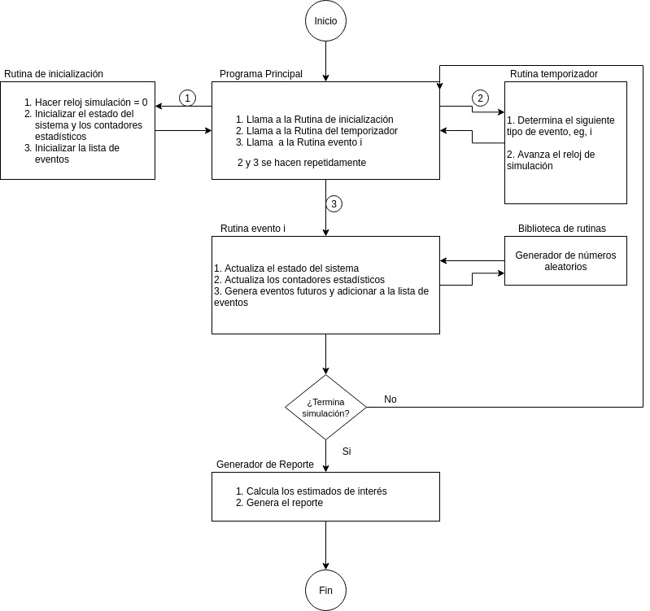

Flujo de una Simulación de Eventos Discretos

A continuación veremos cada uno de los componentes del flujo y su respectivo programa.